# Mapping Median Household Income by Tract in Northern Virginia

# Getting Our Geographic Boundaries

To create our map, we will use the **tigris** package. The tigris package will once again connect to the Census Bureau’s website. This time, however we will use it to grab shape files containing the geographic boundaries and map information necessary for plotting. We will then merge the information we grabbed in the previous section to plot it.

We can grab the boundaries of interest using the **tigris** package’s `tracts` function. This function will take a state and a set of county FIPS codes as arguments. It will then return a Spatial Polygons Data Frame that we can plot. Below, we submit the code to get the information we need for the FIPS codes of interest

```r
#download and create shapefile for Arlington, Fairfax and Alexandria
nova.shape <- tracts(state="VA",county=c("013","059","510","600") )
```

To preview what this looks like, we can simply use the plot function to view its contents

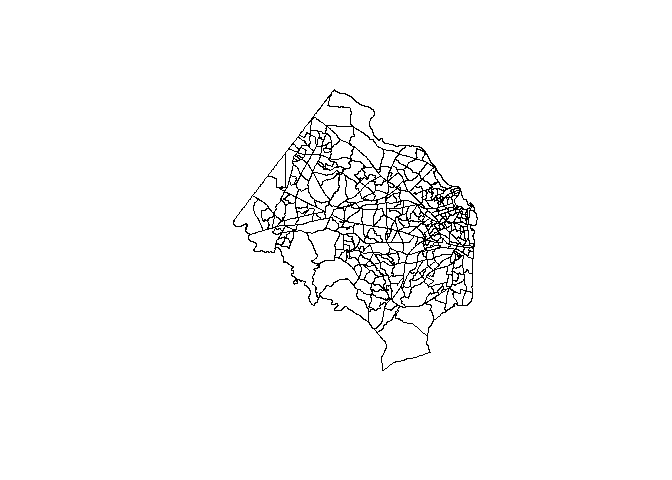

```r
#quick plot to see what it looks like
plot(nova.shape)
```

```r
nova.shape@data %>% head()
```

```
##     STATEFP COUNTYFP TRACTCE       GEOID    NAME             NAMELSAD
## 98       51      510  201801 51510201801 2018.01 Census Tract 2018.01
## 99       51      510  201204 51510201204 2012.04 Census Tract 2012.04
## 100      51      510  200102 51510200102 2001.02 Census Tract 2001.02
## 101      51      510  200105 51510200105 2001.05 Census Tract 2001.05
## 102      51      510  200201 51510200201 2002.01 Census Tract 2002.01
## 110      51      510  200104 51510200104 2001.04 Census Tract 2001.04
##     MTFCC FUNCSTAT   ALAND AWATER    INTPTLAT     INTPTLON
## 98  G5020        S 2803690  98412 +38.8240656 -077.0445733
## 99  G5020        S  486129      0 +38.8341132 -077.0559571
## 100 G5020        S 1121587   2390 +38.8336198 -077.1254615
## 101 G5020        S  188743      0 +38.8327451 -077.1134292
## 102 G5020        S 2178440      0 +38.8272503 -077.0986804
## 110 G5020        S  889826  13370 +38.8287066 -077.1212514
```

You can see that this data frame holds a lot of geographic information, the tigris dataset also gives us nuggets such as land and water area in the tract as well (`ALAND` and `AWATER` variables respectively). We want to link our income data to this data set. We can do this by left joining our income data by the “GEOID” variable.

```r
##Merge out income data onto the spatial dataset
nova.shape@data<-nova.shape@data %>%
  left_join(income_df,by="GEOID") %>%
  filter(median_income>=0)
```

# Leaflet Maps

While it’s nice to see the geographic boundaries, we want for the user to be able to explore the map. Leaflet maps are great for this. They are javascript based maps that allow the user to pan, zoomin, and click on map entities for more information. Luckily for us, the **leaflet** package in R allows use to do this with ease.

To prepare for this, we need to make a color scale. I want dark colors to represent areas with higher median income, while lighting areas represent areas of lower median household income. The leaflet package provides us with the `colorNumeric` function that will create the gradient we want.

```r
### Create Color Pallete for Choropleth
pal<-colorNumeric(palette = "Purples",
                   domain = NULL)
```

We also want to make the user to be able to click for more information. we do this by creating a snippet of HTML that will popup when the user clicks on an area for more information.

```r
#Create "on-click" popup information for out map
# it simply will display the tract number and the
#median income
tract_popup <- paste0("<strong>Tract: </strong>",
                      nova.shape@data$TRACTCE,
                      "<br><strong>",
                      "Value",
                      ": </strong>",
                      paste("$",format(nova.shape@data$median_income, big.mark=",",
                                       trim=TRUE),sep=""))
```

It’s finally the moment we have all been waiting for, it’s time to create out map!!!

```r
#finally create map; view and zoom were set by trial and error
leaflet() %>% setView(lng=-77.2876,
                         lat=38.8041,
                         zoom = 10) %>%
              #Add Map Tiles (the background map)
              addProviderTiles("CartoDB.Positron") %>%
              #Add our Census Tracts and color them
              #using our palette
              #Also inclue pop-ups we created above
              addPolygons(data = nova.shape,weight=1,color="#000000",
                             fillColor=~pal((nova.shape@data$median_income)),
                             fillOpacity = .6,
                             popup=tract_popup) %>%
               #finally include
              addLegend("bottomleft",
                          pal=pal,
                          values =nova.shape@data$median_income,
                          title="Median Family Income",labFormat=labelFormat(prefix = "$"))
```

We finally submit the above code and VOILA! we have the map below.

[interactive chart not shown]

Not too bad right!